"On my honor, as a student, I have neither given nor received unauthorized aid on this academic work."¶

```python
import pandas as pd
import numpy as np
import seaborn as sns
import matplotlib.pyplot as plt
%matplotlib inline

#regression packages
import sklearn.linear_model as lm
from sklearn.metrics import mean_squared_error
from sklearn.metrics import explained_variance_score

import statsmodels.api as sm
from statsmodels.formula.api import ols

#lasso regression
from sklearn import linear_model

#f_regression (feature selection)
from sklearn.feature_selection import f_regression
from sklearn.feature_selection import SelectKBest

# recursive feature selection (feature selection)
from sklearn.feature_selection import RFE

import statsmodels.api as sm
from statsmodels.formula.api import ols
```

# 1) The question (and step) is that you review the problem statement and the description about the columns (or variables) in the dataset, and develop at least two hypotheses1, which you can test using regression on the provided dataset. Provide the rationale for the hypotheses.

## Hypothesis 1: The value of housing is directly correlated to the crime rate in the area. Areas with higher crime will have a lower avg housing value.

## Hypothesis 2: The value of housing is directly correlated to the number of rooms per dwelling.

# 2) Demonstrate your data visualization skills (e.g., charts, pivot tables). You should explore matplot, seaborn, and interactive plots. The focus should be on identifying X variables (independent variables) affecting Y value (dependent variable, MEDV in the dataset). What X variables appear to influence on the median housing price in Boston?

```python
df = pd.read_csv("data/b_housing.csv")
df.head()
```

|  | Unnamed: 0 | crim | zn | indus | chas | nox | rm | age | dis | rad | tax | ptratio | black | lstat | medv |
| --- | --- | --- | --- | --- | --- | --- | --- | --- | --- | --- | --- | --- | --- | --- | --- |
| 0 | 1 | 0.00632 | 18.0 | 2.31 | 0 | 0.538 | 6.575 | 65.2 | 4.0900 | 1 | 296 | 15.3 | 396.90 | 4.98 | 24.0 |
| 1 | 2 | 0.02731 | 0.0 | 7.07 | 0 | 0.469 | 6.421 | 78.9 | 4.9671 | 2 | 242 | 17.8 | 396.90 | 9.14 | 21.6 |
| 2 | 3 | 0.02729 | 0.0 | 7.07 | 0 | 0.469 | 7.185 | 61.1 | 4.9671 | 2 | 242 | 17.8 | 392.83 | 4.03 | 34.7 |
| 3 | 4 | 0.03237 | 0.0 | 2.18 | 0 | 0.458 | 6.998 | 45.8 | 6.0622 | 3 | 222 | 18.7 | 394.63 | 2.94 | 33.4 |
| 4 | 5 | 0.06905 | 0.0 | 2.18 | 0 | 0.458 | 7.147 | 54.2 | 6.0622 | 3 | 222 | 18.7 | 396.90 | 5.33 | 36.2 |

```python
df.info()
```

```
<class 'pandas.core.frame.DataFrame'>
RangeIndex: 506 entries, 0 to 505
Data columns (total 15 columns):
Unnamed: 0    506 non-null int64
crim          506 non-null float64
zn            506 non-null float64
indus         506 non-null float64
chas          506 non-null int64
nox           506 non-null float64
rm            506 non-null float64
age           506 non-null float64
dis           506 non-null float64
rad           506 non-null int64
tax           506 non-null int64
ptratio       506 non-null float64
black         506 non-null float64
lstat         506 non-null float64
medv          506 non-null float64
dtypes: float64(11), int64(4)
memory usage: 59.4 KB
```

```python
df.describe()
```

|  | Unnamed: 0 | crim | zn | indus | chas | nox | rm | age | dis | rad | tax | ptratio | black | lstat | medv |
| --- | --- | --- | --- | --- | --- | --- | --- | --- | --- | --- | --- | --- | --- | --- | --- |
| count | 506.000000 | 506.000000 | 506.000000 | 506.000000 | 506.000000 | 506.000000 | 506.000000 | 506.000000 | 506.000000 | 506.000000 | 506.000000 | 506.000000 | 506.000000 | 506.000000 | 506.000000 |
| mean | 253.500000 | 3.613524 | 11.363636 | 11.136779 | 0.069170 | 0.554695 | 6.284634 | 68.574901 | 3.795043 | 9.549407 | 408.237154 | 18.455534 | 356.674032 | 12.653063 | 22.532806 |
| std | 146.213884 | 8.601545 | 23.322453 | 6.860353 | 0.253994 | 0.115878 | 0.702617 | 28.148861 | 2.105710 | 8.707259 | 168.537116 | 2.164946 | 91.294864 | 7.141062 | 9.197104 |
| min | 1.000000 | 0.006320 | 0.000000 | 0.460000 | 0.000000 | 0.385000 | 3.561000 | 2.900000 | 1.129600 | 1.000000 | 187.000000 | 12.600000 | 0.320000 | 1.730000 | 5.000000 |
| 25% | 127.250000 | 0.082045 | 0.000000 | 5.190000 | 0.000000 | 0.449000 | 5.885500 | 45.025000 | 2.100175 | 4.000000 | 279.000000 | 17.400000 | 375.377500 | 6.950000 | 17.025000 |
| 50% | 253.500000 | 0.256510 | 0.000000 | 9.690000 | 0.000000 | 0.538000 | 6.208500 | 77.500000 | 3.207450 | 5.000000 | 330.000000 | 19.050000 | 391.440000 | 11.360000 | 21.200000 |
| 75% | 379.750000 | 3.677082 | 12.500000 | 18.100000 | 0.000000 | 0.624000 | 6.623500 | 94.075000 | 5.188425 | 24.000000 | 666.000000 | 20.200000 | 396.225000 | 16.955000 | 25.000000 |
| max | 506.000000 | 88.976200 | 100.000000 | 27.740000 | 1.000000 | 0.871000 | 8.780000 | 100.000000 | 12.126500 | 24.000000 | 711.000000 | 22.000000 | 396.900000 | 37.970000 | 50.000000 |

```python
df.isnull().sum()
```

```
Unnamed: 0    0
crim          0
zn            0
indus         0
chas          0
nox           0
rm            0
age           0
dis           0
rad           0
tax           0
ptratio       0
black         0
lstat         0
medv          0
dtype: int64
```

```python
df.columns
```

```
Index([u'Unnamed: 0', u'crim', u'zn', u'indus', u'chas', u'nox', u'rm', u'age',
       u'dis', u'rad', u'tax', u'ptratio', u'black', u'lstat', u'medv'],
      dtype='object')
```

```python
mean = df['medv'].mean()
med = df['medv'].median()
mean = mean * 1000
med = med*1000
print ("mean house value: ", mean,"median house value is: ", med)
```

```
('mean house value: ', 22532.806324110697, 'median house value is: ', 21200.0)
```

```python
import pandas as pd
import numpy as np
import matplotlib.pyplot as plt
import seaborn as sns

%matplotlib inline
```

## data visualization

[figure not shown]

```python
sns.factorplot("crim", "medv", data=df)
```

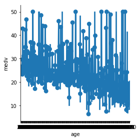

```python
sns.factorplot("age", "medv", data=df)
```

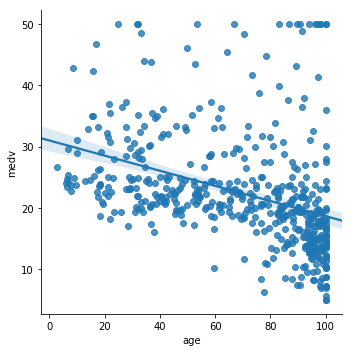

```python
sns.lmplot("age", "medv", df)
```

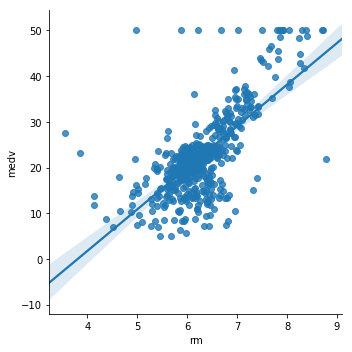

```python
sns.lmplot("rm", "medv", df)
```

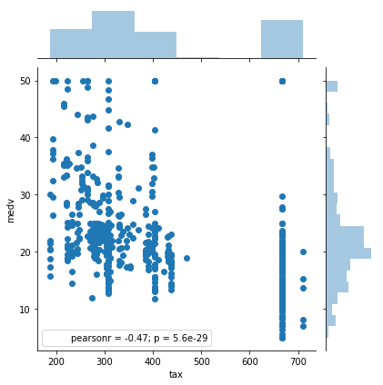

```python
sns.jointplot("tax", "medv", df)
```

## negative correlation between crime and mean property value

## strong correlation between rms and home value

# 3) Demonstrate your exploratory data analysis (EDA) skills (e.g., correlation analysis, heatmap). What X variables appear to influence on the median housing price in Boston? What X variables are highly correlated to each other?

```python
df.corr()
```

|  | Unnamed: 0 | crim | zn | indus | chas | nox | rm | age | dis | rad | tax | ptratio | black | lstat | medv |
| --- | --- | --- | --- | --- | --- | --- | --- | --- | --- | --- | --- | --- | --- | --- | --- |
| Unnamed: 0 | 1.000000 | 0.407407 | -0.103393 | 0.399439 | -0.003759 | 0.398736 | -0.079971 | 0.203784 | -0.302211 | 0.686002 | 0.666626 | 0.291074 | -0.295041 | 0.258465 | -0.226604 |
| crim | 0.407407 | 1.000000 | -0.200469 | 0.406583 | -0.055892 | 0.420972 | -0.219247 | 0.352734 | -0.379670 | 0.625505 | 0.582764 | 0.289946 | -0.385064 | 0.455621 | -0.388305 |
| zn | -0.103393 | -0.200469 | 1.000000 | -0.533828 | -0.042697 | -0.516604 | 0.311991 | -0.569537 | 0.664408 | -0.311948 | -0.314563 | -0.391679 | 0.175520 | -0.412995 | 0.360445 |
| indus | 0.399439 | 0.406583 | -0.533828 | 1.000000 | 0.062938 | 0.763651 | -0.391676 | 0.644779 | -0.708027 | 0.595129 | 0.720760 | 0.383248 | -0.356977 | 0.603800 | -0.483725 |
| chas | -0.003759 | -0.055892 | -0.042697 | 0.062938 | 1.000000 | 0.091203 | 0.091251 | 0.086518 | -0.099176 | -0.007368 | -0.035587 | -0.121515 | 0.048788 | -0.053929 | 0.175260 |
| nox | 0.398736 | 0.420972 | -0.516604 | 0.763651 | 0.091203 | 1.000000 | -0.302188 | 0.731470 | -0.769230 | 0.611441 | 0.668023 | 0.188933 | -0.380051 | 0.590879 | -0.427321 |
| rm | -0.079971 | -0.219247 | 0.311991 | -0.391676 | 0.091251 | -0.302188 | 1.000000 | -0.240265 | 0.205246 | -0.209847 | -0.292048 | -0.355501 | 0.128069 | -0.613808 | 0.695360 |
| age | 0.203784 | 0.352734 | -0.569537 | 0.644779 | 0.086518 | 0.731470 | -0.240265 | 1.000000 | -0.747881 | 0.456022 | 0.506456 | 0.261515 | -0.273534 | 0.602339 | -0.376955 |
| dis | -0.302211 | -0.379670 | 0.664408 | -0.708027 | -0.099176 | -0.769230 | 0.205246 | -0.747881 | 1.000000 | -0.494588 | -0.534432 | -0.232471 | 0.291512 | -0.496996 | 0.249929 |
| rad | 0.686002 | 0.625505 | -0.311948 | 0.595129 | -0.007368 | 0.611441 | -0.209847 | 0.456022 | -0.494588 | 1.000000 | 0.910228 | 0.464741 | -0.444413 | 0.488676 | -0.381626 |
| tax | 0.666626 | 0.582764 | -0.314563 | 0.720760 | -0.035587 | 0.668023 | -0.292048 | 0.506456 | -0.534432 | 0.910228 | 1.000000 | 0.460853 | -0.441808 | 0.543993 | -0.468536 |
| ptratio | 0.291074 | 0.289946 | -0.391679 | 0.383248 | -0.121515 | 0.188933 | -0.355501 | 0.261515 | -0.232471 | 0.464741 | 0.460853 | 1.000000 | -0.177383 | 0.374044 | -0.507787 |
| black | -0.295041 | -0.385064 | 0.175520 | -0.356977 | 0.048788 | -0.380051 | 0.128069 | -0.273534 | 0.291512 | -0.444413 | -0.441808 | -0.177383 | 1.000000 | -0.366087 | 0.333461 |
| lstat | 0.258465 | 0.455621 | -0.412995 | 0.603800 | -0.053929 | 0.590879 | -0.613808 | 0.602339 | -0.496996 | 0.488676 | 0.543993 | 0.374044 | -0.366087 | 1.000000 | -0.737663 |
| medv | -0.226604 | -0.388305 | 0.360445 | -0.483725 | 0.175260 | -0.427321 | 0.695360 | -0.376955 | 0.249929 | -0.381626 | -0.468536 | -0.507787 | 0.333461 | -0.737663 | 1.000000 |

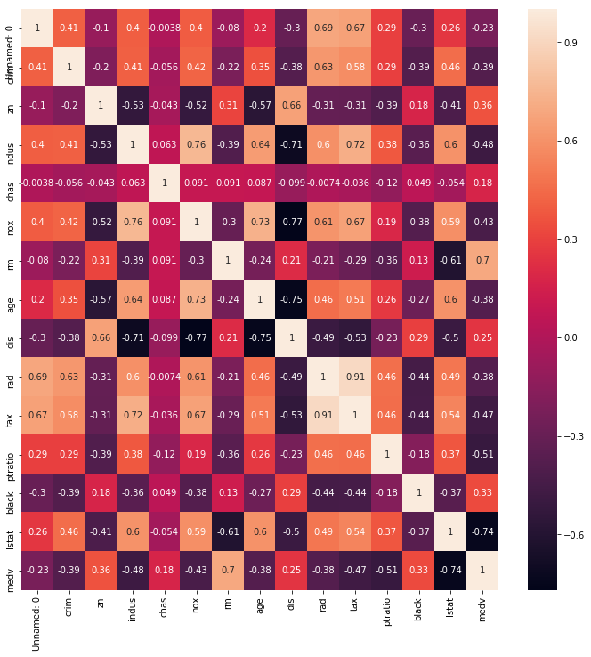

```python
plt.figure(figsize=(12,12))
sns.heatmap(df.corr(),annot=True)
```

# Analysis

```python
sns.lmplot('OBP', 'R', teams)
```

[output not shown]

```python
df.columns
```

```
Index([u'Unnamed: 0', u'crim', u'zn', u'indus', u'chas', u'nox', u'rm', u'age',
       u'dis', u'rad', u'tax', u'ptratio', u'black', u'lstat', u'medv'],
      dtype='object')
```

# 4) Demonstrate your skills in building and evaluating regression models. Initially, you need to build a multiple regression model. It is important that you use both scikit-learn2 and statmodel. You need to report the regression results and provide your interpretations (e.g., coefficients, p-value, R-squared).

```python
y = df['medv']
X = df[['crim','zn','indus','chas','nox','rm','age','dis','rad','tax','ptratio','black','lstat']]
model1 = lm.LinearRegression()
model1.fit(X, y)
model1_y = model1.predict(X)
```

```python
print 'Coefficients: ', model1.coef_
print "y-intercept ", model1.intercept_
```

```
Coefficients:  [-1.08011358e-01  4.64204584e-02  2.05586264e-02  2.68673382e+00
 -1.77666112e+01  3.80986521e+00  6.92224640e-04 -1.47556685e+00
  3.06049479e-01 -1.23345939e-02 -9.52747232e-01  9.31168327e-03
 -5.24758378e-01]
y-intercept  36.459488385090935
```

```python
print "mean square error: ", mean_squared_error(y, model1_y)
print "variance or r-squared: ", explained_variance_score(y, model1_y)
```

```
mean square error:  21.894831181729206
variance or r-squared:  0.7406426641094094
```

## Stats model

```python
runs_reg_model = ols("medv~crim+rm+black+tax+age+dis+ptratio+lstat+nox",df)
runs_reg = runs_reg_model.fit()
print runs_reg.summary()
```

```
                            OLS Regression Results
==============================================================================
Dep. Variable:                   medv   R-squared:                       0.717
Model:                            OLS   Adj. R-squared:                  0.712
Method:                 Least Squares   F-statistic:                     140.0
Date:                Mon, 22 Oct 2018   Prob (F-statistic):          4.87e-130
Time:                        19:27:43   Log-Likelihood:                -1520.4
No. Observations:                 506   AIC:                             3061.
Df Residuals:                     496   BIC:                             3103.
Df Model:                           9
Covariance Type:            nonrobust
==============================================================================
                 coef    std err          t      P>|t|      [0.025      0.975]
------------------------------------------------------------------------------
Intercept     30.4019      5.076      5.989      0.000      20.428      40.376
crim          -0.0606      0.033     -1.859      0.064      -0.125       0.003
rm             4.4189      0.419     10.544      0.000       3.595       5.242
black          0.0090      0.003      3.245      0.001       0.004       0.014
tax            0.0016      0.002      0.737      0.462      -0.003       0.006
age           -0.0067      0.014     -0.492      0.623      -0.033       0.020
dis           -1.2184      0.182     -6.691      0.000      -1.576      -0.861
ptratio       -1.0140      0.124     -8.148      0.000      -1.258      -0.769
lstat         -0.5223      0.052     -9.961      0.000      -0.625      -0.419
nox          -16.0309      3.800     -4.219      0.000     -23.496      -8.566
==============================================================================
Omnibus:                      208.525   Durbin-Watson:                   0.966
Prob(Omnibus):                  0.000   Jarque-Bera (JB):             1109.398
Skew:                           1.744   Prob(JB):                    1.25e-241
Kurtosis:                       9.360   Cond. No.                     1.45e+04
==============================================================================

Warnings:
[1] Standard Errors assume that the covariance matrix of the errors is correctly specified.
[2] The condition number is large, 1.45e+04. This might indicate that there are
strong multicollinearity or other numerical problems.
```

```python
runs_reg.mse_resid
```

```
24.331185962788624
```

```python
runs_reg.params
```

```
Intercept    30.401860
crim         -0.060569
rm            4.418875
black         0.009025
tax           0.001609
age          -0.006683
dis          -1.218363
ptratio      -1.013960
lstat        -0.522350
nox         -16.030948
dtype: float64
```

# 5) Demonstrate your understanding of advanced regression techniques such as regularization and feature selection. Now, you need to build regression models using regularization and feature selection. The goal is to find the best regression model, which is (1) complex enough to be realistic and (2) simple enough to be practical. a) Regression model based on regularization b) Regression model based on Feature selection

```python
y = df['medv']
X = df[['crim','zn','indus','chas','nox','rm','age','dis','rad','tax','ptratio','black','lstat']]
model2 =   lm.Lasso(alpha = 0.1)
model2.fit(X, y)
model2_y = model2.predict(X)
```

```python
print 'Coefficients: ', model2.coef_
print "y-intercept ", model2.intercept_
```

```
Coefficients:  [-0.09789363  0.04921111 -0.03661906  0.95519003 -0.          3.70320175
 -0.01003698 -1.16053834  0.27470721 -0.01457017 -0.77065434  0.01024917
 -0.56876914]
y-intercept  25.577073179662136
```

```python
print "mean square error: ", mean_squared_error(y, model2_y)
print "variance or r-squared: ", explained_variance_score(y, model2_y)
```

```
mean square error:  23.04793291321172
variance or r-squared:  0.7269834862602695
```

```python
coef = ["%.3f" % i for i in model1.coef_]
xcolumns = [ i for i in X.columns ]
zip(xcolumns, coef)
```

[output not shown]

## Ridge

```python
rig =   lm.Ridge(alpha = 0.9)           #higher alpha (penality parameter), fewer predictors
rig.fit(X, y)
rig_y = rig.predict(X)
```

```python
print 'Coefficients: ', rig.coef_
print "y-intercept ", rig.intercept_
```

```
Coefficients:  [-1.04805214e-01  4.73738800e-02 -6.95950459e-03  2.56355091e+00
 -1.12184157e+01  3.85224055e+00 -5.03953281e-03 -1.37914619e+00
  2.91098724e-01 -1.28730078e-02 -8.80837098e-01  9.65073168e-03
 -5.32720322e-01]
y-intercept  31.895866146735543
```

```python
coef = ["%.3f" % i for i in rig.coef_]
xcolumns = [ i for i in X.columns ]
zip(xcolumns, coef)
```

```
[('crim', '-0.105'),
 ('zn', '0.047'),
 ('indus', '-0.007'),
 ('chas', '2.564'),
 ('nox', '-11.218'),
 ('rm', '3.852'),
 ('age', '-0.005'),
 ('dis', '-1.379'),
 ('rad', '0.291'),
 ('tax', '-0.013'),
 ('ptratio', '-0.881'),
 ('black', '0.010'),
 ('lstat', '-0.533')]
```

```python
print "mean square error: ", mean_squared_error(y, rig_y)
print "variance or r-squared: ", explained_variance_score(y, rig_y)
```

```
mean square error:  22.026112750369606
variance or r-squared:  0.7390875556177521
```

## Feature selection

```python
X_new = SelectKBest(f_regression, k=2).fit_transform(X, y)
X_new
```

```
array([[6.575, 4.98 ],
       [6.421, 9.14 ],
       [7.185, 4.03 ],
       ...,
       [6.976, 5.64 ],
       [6.794, 6.48 ],
       [6.03 , 7.88 ]])
```

```python
model3 = lm.LinearRegression()
model3.fit(X_new, y)
model3_y = model3.predict(X_new)

print "mean square error: ", mean_squared_error(y, model3_y)
print "variance or r-squared: ", explained_variance_score(y, model3_y)
```

```
mean square error:  30.51246877729947
variance or r-squared:  0.6385616062603403
```

```python
X_new = SelectKBest(f_regression, k=3).fit_transform(X, y)
model4 = lm.LinearRegression()
model4.fit(X_new, y)
model4_y = model4.predict(X_new)


print "mean square error: ", mean_squared_error(y, model4_y)
print "variance or r-squared: ", explained_variance_score(y, model4_y)
```

```
mean square error:  27.130405758497062
variance or r-squared:  0.6786241601613111
```

## Recursive Feature Selection (RFE)

```python
lr = lm.LinearRegression()
rfe = RFE(lr, n_features_to_select=2)
rfe_y = rfe.fit(X,y)

print "Features sorted by their rank:"
print sorted(zip(map(lambda x: x, rfe.ranking_), X.columns))
```

```
Features sorted by their rank:
[(1, 'nox'), (1, 'rm'), (2, 'chas'), (3, 'ptratio'), (4, 'dis'), (5, 'lstat'), (6, 'rad'), (7, 'crim'), (8, 'indus'), (9, 'zn'), (10, 'tax'), (11, 'black'), (12, 'age')]
```

# 6) Demonstrate your skills in model selection and storytelling. At this stage, you have chosen the best regression model for predicting Boston housing prices.

## B) How good is your model? You can visualize actual vs. predictive using a scatter plot.

```python
from sklearn.preprocessing import normalize


X_normalized = normalize(X)

X_normalized
```

```
array([[1.26388341e-05, 3.59966795e-02, 4.61957387e-03, ...,
        3.05971776e-02, 7.93726783e-01, 9.95908132e-03],
       [5.78529889e-05, 0.00000000e+00, 1.49769546e-02, ...,
        3.77071843e-02, 8.40785474e-01, 1.93620036e-02],
       [5.85729947e-05, 0.00000000e+00, 1.51744622e-02, ...,
        3.82044450e-02, 8.43137761e-01, 8.64965806e-03],
       ...,
       [1.23765824e-04, 0.00000000e+00, 2.43009593e-02, ...,
        4.27762066e-02, 8.08470305e-01, 1.14884669e-02],
       [2.24644719e-04, 0.00000000e+00, 2.44548909e-02, ...,
        4.30471676e-02, 8.06519433e-01, 1.32831260e-02],
       [9.69214289e-05, 0.00000000e+00, 2.43887924e-02, ...,
        4.29308164e-02, 8.11392431e-01, 1.61092778e-02]])
```

```python
from sklearn.preprocessing import Normalizer

y = df['medv']
X = df.drop(['medv'], axis =1)

scaler = Normalizer().fit(X)
normalizedX = scaler.transform(X)
normalizedX
```

```
array([[1.99981153e-03, 1.26388089e-05, 3.59966075e-02, ...,
        3.05971164e-02, 7.93725195e-01, 9.95906141e-03],
       [4.23672425e-03, 5.78524697e-05, 0.00000000e+00, ...,
        3.77068458e-02, 8.40777928e-01, 1.93618298e-02],
       [6.43881793e-03, 5.85717805e-05, 0.00000000e+00, ...,
        3.82036531e-02, 8.43120283e-01, 8.64947876e-03],
       ...,
       [7.16336000e-01, 8.63582845e-05, 0.00000000e+00, ...,
        2.98473333e-02, 5.64114600e-01, 8.01614095e-03],
       [7.19222975e-01, 1.56078507e-04, 0.00000000e+00, ...,
        2.99082821e-02, 5.60353029e-01, 9.22884134e-03],
       [7.18970073e-01, 6.73643699e-05, 0.00000000e+00, ...,
        2.98386789e-02, 5.63951031e-01, 1.11966090e-02]])
```

```python
model = lm.LinearRegression()
model.fit(normalizedX, y)
model_y = model.predict(normalizedX)
print 'Coefficients: ', model.coef_
print "y-intercept ", model.intercept_
```

```
Coefficients:  [ 5.98754135e+00 -1.04518817e+02  2.05859905e+01  2.31078587e+01
  1.37015575e+03 -5.91155188e+03  3.04015798e+03 -6.06305459e-01
 -5.99556357e+02  1.91768561e+02  4.61200971e+00 -3.92345786e+02
  1.35577251e+01 -2.59746983e+02]
y-intercept  0.7366133815421811
```

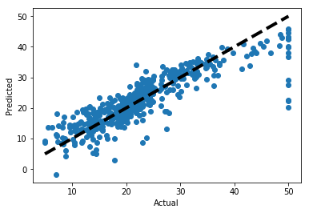

```python
plt.subplots()
plt.scatter(y, model_y)
plt.plot([y.min(), y.max()], [y.min(), y.max()], 'k--', lw=4)   #dotted line represents perfect prediction (actual = predicted)
plt.xlabel('Actual')
plt.ylabel('Predicted')
plt.show()
```